# Lab 2: Intertidal Gradient Experiment Analysis

# 1 Learning outcomes

1. Learn ecological field experimental methods (transects, quadrats. etc.)
2. Learn about gradients
3. Learn about the natural history of the Northeastern Intertidal zone
4. Introduction to R and RStudio

# 2 Background

## 2.1 Single species population growth

Thus far in lecture we have focused on answering the question: **What affects population growth?** We have begun at the most simple level by focusing on growth of single species, and how intrinsic factors (e.g., crowding, demography, space) affect growth. Implicit what you’ve learned is that environments are homogeneous (i.e., there are no extrinsic factors affecting growth). We know this isn’t the case, and we will later explore in lecture how extrinsic factors in populations’ environments (e.g., temperatures, moisture, predator and mutualist abundances) affect growth as well. For now, however, without going into much depth, a primary purpose of this experiment will be to learn to use ecological methods to quantify population size across different environments.

## 2.2 Adaptation to specific environments

No single species is adapted to all environments. That is, there is no single species that grows atop Earth’s highest mountains, deep in the ocean’s trenches, in hydrothermal vents (115°C, or 239°F), and on glaciers. Can you even begin to fathom what types of physiological machinery would be needed to survive and reproduce in all of those environments and in all of the environments on Earth? Presumably it’s biologically impossible or, in all likelihood, species that specialize to a degree tend to have higher fitness than species that generalize. Over time, through the process of evolution, many species tend to indeed become specialized to specific environments through the process of adaptation. In order for adaptation to occur, there needs to be four ingredients:

1. Relatively high fitness in the environment to which the species adapts
2. Heritable trait(s) that increase fitness in the environment to which the species adapts
3. Sufficient genetic isolation for the species in the environment to which it will adapt
4. Time for the process to happen

## 2.3 Intertidal encompass a multiplicity of environmental conditions

One of the most unique environments on Earth, in our humble opinions, is the rocky intertidal zone. In this environment, there is an enormous amount of variation in environmental conditions in a relatively small space and they can change in a relatively small amount of time. Furthermore, these characteristics tend to continuously vary from the highest point of the Intertidal zone (the splash zone) to the lowest point (the subtidal zone). The conditions that vary across the rocky intertidal zone include:

- **Submergence**: there’s a continuous gradient of the amount of time that parts of the intertidal zone spends underwater, with the upper parts being submerged the least and the lower parts being submerged the most. Note that the tidal cycle varies roughly on a 12-hr time scale from high to low tides, but also on a half-monthly cycle with spring and neap tides ([information here](https://oceanservice.noaa.gov/facts/springtide.html)).
- **Temperature**: as the tides wax and wane, the amount of time the shore spends submerged or exposed directly influences temperature in a dramatic fashion across a continuous gradient, with the upper parts the warmest on average and the lowest parts the coolest on average. Note too, that there is larger *variation* in temperature in the upper parts compared with the lower parts.
- **Wave action**: as many of you have experienced at beaches, the force of waves is not an inconsequential condition for organisms that live on the marine-terrestrial interface. With the change in tide also comes a change in exposure to wave action, with the upper parts receiving the greatest action on average and the lower parts receiving the least action on average. Wave action also has greater variance at higher parts.
- **UV exposure**: ultraviolet light is harmful; for instance, medium-wavelength ultraviolet light (UV-B) is primarily responsible for sunburns and short-wavelength ultraviolet light (UV-A) is primarily responsible for long-term skin damage such as basal and squamous cell carcinomas ([How does sunscreen protect skin?](https://www.scientificamerican.com/article/how-does-sunscreen-protec/)). Seawater reflects ultraviolet light to a degree, meaning that with the changing tides that upper parts receive more ultraviolet light radiation than lower parts.
- **Salinity**: osmoregulation is a very important and energetically expensive physiological process. Because of this, most organisms exist within a narrow range of salinity in their environments. For example, this is why we observe many types of freshwater organisms, many types of marine organisms, but very, very few that exist in both marine and freshwater environments. Marine environments are pretty constantly at about 35 grams of dissolved salt per liter of water (35 ppt or 3.5%), while freshwater generally ranges from 0 to 0.5 ppt. In intertidal areas, as exposure varies with the tides, in places with regular precipitation, organisms in the upper parts can have salinity levels vary dramatically in their environments.
- **Resource availability**: even though we’ve covered how conditions change across the intertidal zone, resources that can be consumed by organisms also changes. Resource use might include: photosynthetic algae and cyanobacteria consuming inorganic nutrients, filter feeding organisms needing water to filter out and consume plankton, predators consuming prey, herbivores consuming algae or plant matter, and space itself is a resource that is temporarily “consumed”. You can imagine that resource availability too varies across the intertidal, with lower parts generally with more resources compared with the upper parts.

## 2.4 Using the intertidal zone to determine how environmental conditions affect abundance

Again, for this lab we are interested in how single-species populations are affected by environmental conditions. Organisms are all adapted to their environments to some extent, and the intertidal zone harbors a wide array of environments that species exist in today. We therefore expect that these species adapted to environments in the intertidal will exhibit patterns of abundance directly related to the extent to which they are adapted to a specific set of environmental conditions. The goal for this lab is to determine a set of environmental conditions to which two types of organisms: (1) barnacle (mostly acorn, *Semibalanus balanoides*) and (2) brown algae including bladderwrack (*Fucus vesiculosus*) and knotted wrack (*Ascophyllum nodosum*).

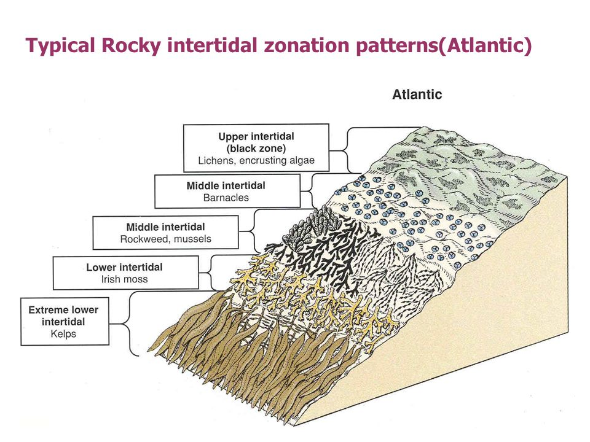

# 3 Experiment

The over-arching hypothesis that you will be testing will be that

> if the environmental conditions to which a species has adapted changes continously along a gradient, then we expect to see corresponding changes in the abudnace of that species, with abudance being greatest in the areas that most closely match the contidions to which the organisms are adapted.

An environmental gradient is gradual change in abiotic conditions that often varies continuously in space or time. A conceptual figure below shows how we expect abundance to change, dependent upon the the environmental condition continuously changing across a gradient:

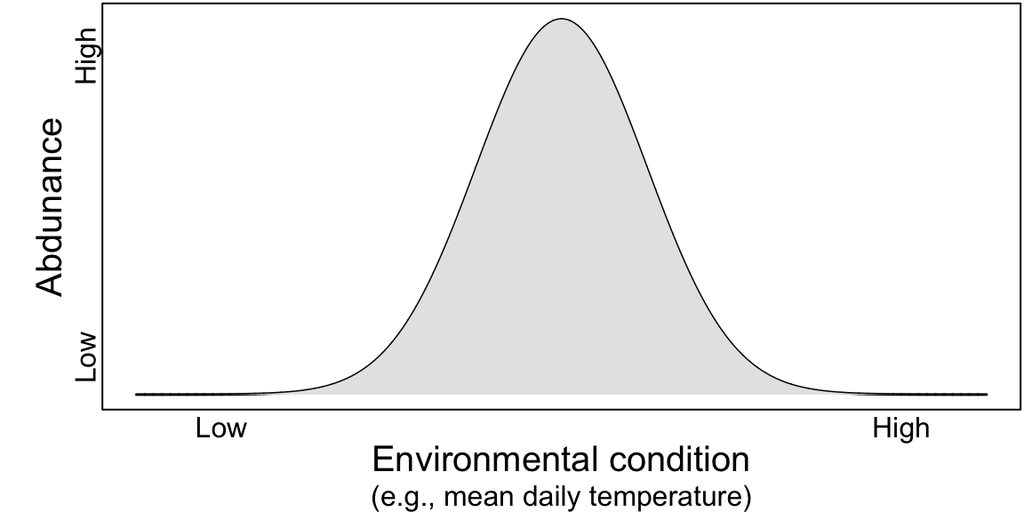

The goal for this lab is to determine a set of environmental conditions to which two types of organisms: (1) barnacle (mostly acorn, *Semibalanus balanoides*) and (2) brown algae including bladderwrack (*Fucus vesiculosus*) and knotted wrack (*Ascophyllum nodosum*).

The 4 environmental conditions that you will be quantifying as predictor variables of barnacle and brown algae abundances are:

1. Distance from upper limit of upper intertidal (m)
2. Depth from upper limit of upper intertidal (m)
3. Substrate temperature, preferably bare rock (°C)
4. Bearing (exposed south-facing or protected east-facing)

and the two types of organisms whose density you will quantify as response variables to environmental conditions are:

1. Density of barnacles (percent cover per 0.25 m<sup>2</sup>)
2. Density of bladder wrack or knotted wrack (percent cover per 0.25 m<sup>2</sup>)

## 3.1 Data collection protocol

Completed last week.

# 4 Analysis in R and RStudio

## 4.1 Designate a place to work: create a folder and set the working directory

A useful first step preceding every project that’s performed on your computer is to designate a place to work. This place, commonly referred to as a project’s “working directory,” will generally contain all the files and folders that you’ll need for the project, such as data sets, figures, a report, etc. Additionally, for the sake of this course, it’s probably a good idea to create a working directory within folders for the course and lab, and today’s project could be one of a few lab folders. For example, in Chris Moore’s documents directory, he has a `BI271` folder with `Lab` and `Lecture` folders:

```
## /Users/cmmoore/Documents/BI271
## ├── Lab
## │   ├── Lab1_Gradients
## │   ├── Lab2_PopGrowth
## │   ├── Lab3_Bog
## │   ├── Lab4_Landscape
## │   └── Lab5_Decomposition
## └── Lecuture
```

Notice that within `Lab` there are directories for each of the labs. In terms of organization, we would suggest having a setup similar to this. This allows for you to place documents, data files, figures, etc. all within a folder that is relatively easy to locate and gives you consistency when working on projects for lab. (Life hack: you could do this for all of your classes each semester, too.)

Now that you have a working directory, let’s tell R where it is. First, let’s see where our current working directory is. Do this by typing the command `getwd()` into your console

```r
getwd()
```

```
## [1] "/Users/cmmoore/ColbyDrive/BI271/2018_Fall/Lab/Gradients"
```

This means if we ask R to open a file (such as data) or save a file (such as a figure), that’s where in your computer R will look. Let’s then tell R to set the working directory to the one we just created. Mine is at `"/Users/cmmoore/Desktop/BI271/Lab/Lab1_Gradients"`, and yours will be different. We set the working directory using `setwd()`, with your working directory in quotations. Do that, then check your working directory.

```r
setwd("/Users/cmmoore/Desktop/BI271/Lab/Lab1_Gradients")
getwd()
```

## 4.2 Import and export data and figures from your working directory

### 4.2.1 Create R Script

We will begin working in a text editor in RStudio so we can write and save commands for the project. Create a new R Script file by using the drop downs from the Application Menu Bar. It’s a nice, clean blank slate that you’ll be using for your analysis. The first thing that you want to do is set your working directory. Mine is:

```r
setwd("/Users/cmmoore/Desktop/BI271/Lab/Lab1_Gradients")
```

This ensures that whenever you open this script, you know where the working directory is and with a simple run command, R will know, too.

### 4.2.2 Importing data

Next, we want to import our data. If you haven’t already saved your data as a `.csv` file in the working directory, please do so. There are several different ways of importing data into R, but we will show you the most fail-safe way of doing it in a way that will make your life much easier. That is, if you want a single command to import your data, instead of having to click a bunch of buttons every time you open your Script to get your file, then use the command `read.csv()`. The argument that you will give `read.csv()` is `file =` with the file name in quotes on the right-hand side. For instance, if our data was in a file named `Gradients.csv`, then we’d type:

```r
read.csv(file = "Gradients.csv")
```

You should see your data print out in the console. We want to create an object that we can manipulate and has a name that is informative and easy to type since we’ll by tying it over and over and over again. Let’s assign it a name like `grad`, short for “gradient:

```r
grad <- read.csv(file = "Gradients.csv")
```

Now, if you type `grad` into your console and run it, you should see your data is right there (hooray!).

### 4.2.3 Exporting figures

Now that you have set your working directory you can export figures there very easily. For most of the work done in this class, you’ll probably want to export your figure as a .pdf, only for the reason that they look really nice. To do so, you first want to run the function `pdf()`, then what you want to plot, then `dev.off()`. This tells R to start remembering what to plot, then you plot, then the plotting device to stop. If we wanted to plot $f(u) = u^2$, we’d do the following:

```r
pdf(file = "fu.pdf")
  u <- seq(from = -5, to = 5, by = 0.01)
  fu <- u^2
  plot(x = u, y = fu, xlab = "u", ylab = "f(u)", type = "l")
dev.off()
```

Now, when you look in your directory folder, you should see a .pdf file called `fu.pdf`.

Since it arises frequently, we want to show you how to easily change the size of the pdf file. It’s actually quite simple: use the arguments `width =` and `height =` followed by numeric values in inches as the unit. For example, if I wanted the plot above be 2 by 3 inches, I’d type something along the `pdf(file = "fu.pdf", height = 2, width = 3)`.

## 4.3 Data preparation

Next, have a look over your data. Certainly, this data set is small enough that you could probably visually see some patterns looking at the raw values. This obviously wouldn’t work for many data sets, especially if you are working with genomic, climatological, neuron-mapping, or other types of large data sets. Nevertheless, let’s explore our data using R like we might for a large data set instead of only visually exploring it.

A useful first step to take is to first examine the structure of your data. When you import it, R guesses what types of data you have based upon the values in each column. That is, for the abundance data, R probably guessed they’re numeric data. For the column with group identifiers, then R probably guessed those are character or factor data. Examining the structure of your data set will reveal if R guessed wrong, which means that there’s something incorrect in your data set. So let’s try: run `str()` with your data set object within the parentheses. E.g.,

```r
str(grad)
```

Let’s break this down. The first thing you should see is that your data set is a `data.frame`. That’s good, as that’s how `read.csv()` imports your data. A data frame is a type of data structure in R that requires that the data type is the same within columns, but not between. This is common for most types of collected data. Next, you’ll see the number of rows (called `obs.` for observations) and the number of columns (called `variables`). Below that you’ll see each column/variable listed by its name, followed by the data type (generally, integer, numeric, character, factor, data), lastly followed by the first 10 values.

Another good way to look at the broad structure of your data is to use the function `summary()` on your object. This reports some summary statistics on each column/variable within your data frame. For numeric, integer, and date data `summary()` reports the minimum and maximum values, the 1<sup>st</sup> through 3<sup>rd</sup> quartiles (the values at 25%, 50%, and 75% of your data; the 50% is the median), and mean. For factor and character data, show the most common 6 entries and their counts. For all data, the number of entries with nothing, denoted as `NA`, are reported.

Take a good look over the data. If there’s anything that doesn’t look right, fix it. You can do it in R, but since you are probably new-ish to R, we suggest returning to your spreadsheet program (e.g., Google Sheets), re-saving as a .csv, re-importing it to R, then running `str()` and `summary()` over it again until the errors have been hammered out.

## 4.4 Manipulating data in a dataframe

### 4.4.1 Indexing columns

For the problem sets you’ve already been importing data and indexing columns and rows in the data sets. There are two ways of indexing **data frame** columns in R: appending (1) brackets followed by the column number and (2) dollar signs followed by the column name. For example, if I wanted the first column of the `grad` data frame we created above, we could use `grad[, 1]` or `grad$Group_ID`. If we wanted to index multiple columns, we could, for example, `grad[ , 4:10]`, `grad[ , c(2, 5, 9)]`, or `grad[c("distance", "angle")]`.

### 4.4.2 Creating new columns

Creating new columns on a data frame is easy. You must be adding a column with the same number of rows as the data frame, then type the data frame name, a dollar sign, the new column name, the assignment operator, followed by the data. For example, to add a new column with a bunch of stuff in it, you’d type:

```r
# This literally creates a set of the word "Stuff", with the number of times being the number of rows in your data
grad$NewData <- rep(x = "Stuff", times = nrow(grad))
```

Now, when you look at the names of your columns (e.g., `colnames(grad)`) you’ll see that one called `NewData` has appeared. Index it and you’ll see all of the “Stuff” you created.

### 4.4.3 Indexing rows

Using these data frames, you index rows the same way as you have for lecture: e.g., `grad[20:45, ]`.

## 4.5 Examining a single variable

### 4.5.1 Generate descriptive statistics about the variable

You can run a multitude of commands (synonymous with “function”) that will return statistics that you probably will want to use at some point over your data. Here are a few of the most common operations for summary statistics:

| Function | Return |
| --- | --- |
| `min()` | The minimum value |
| `max()` | The maximum value |
| `range()` | The minimum and maximum values |
| `length()` | The number of values |
| `mean()` | The arithmetic mean |
| `median()` | The middle value (50th %) |
| `quantile()` | The 0, 25, 50, 75, and 100-th % of the values |
| `var()` | The variance |
| `sd()` | The standard deviation |

You’re probably familiar with most of these operations. If not, that’s OK, we just wanted to compile a list of some of ones most of you would find to be most useful.

### 4.5.2 Create graphical summaries about the variable

#### 4.5.2.1 Histograms and box plots

So far you’ve coarsely and more finely explored your data, looking at raw or summary values. Another way to explore your data is to graph it. First, it’s always important to look at the variables individually using a histogram. A histogram is a diagram consisting of rectangles whose area is proportional to the frequency of a variable and whose width is equal to a regularly-spaced interval called a bin. For instance, a histogram for birthdays of students in *Ecology* would have dates on the horizontal axis and the numbers of students birthdays that fall on those dates on the vertical axis. The dates can be individual days (365 bins), weeks (52 bins), months (12 bins), or any other interval you desire that will help you understand and describe your data. Looking at the variables individually will help you understand their distributions. For example, if you measured the heights of people in your *Ecology* lecture, it will probably be somewhat *bimodal*. That is, the most common heights for the males and females will be different, meaning the distribution of heights will likely have two modes, like Bactrian camels (*Camelus bactrianus*). It’s important to know the distribution of your data because you might want to describe or somehow account for that difference. For instance, you might have many 0s in your data, there might be outlying points, or there might be many other deviations from common *a priori* expectations of distributions that they are normally distributed. Normal distributions are technically known as Gaussian distributions, colloquially known as “bell curves,” and graphically look like this (for a mean of 0 and standard deviation of 1):

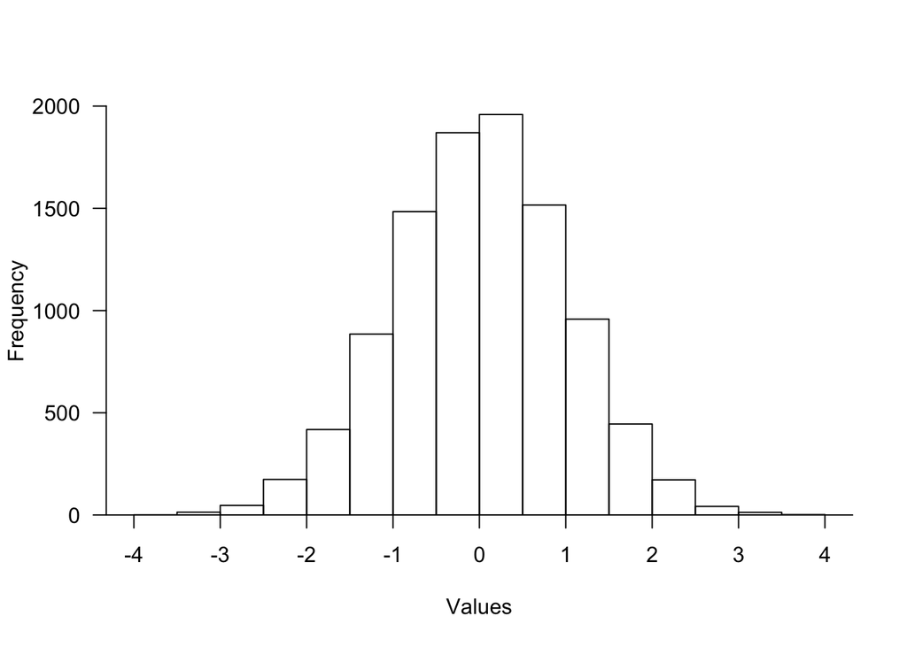

To create a histogram in R, use the function `hist()` over a variable, like one of your columns with numeric data in it. One of the arguments that you’ll find useful is `breaks =`, with the right-hand side being an integer of the number of bins you want. Try `4` or try `400`! A second way to examine a variable in a way to visualize its distribution is by using the function `boxplot()`. You’ve used these in *Evolution and Diversity*, and they make a great tool for summarizing the distribution of data. Below is a histogram and box plot of *the same* Gaussian Distribution:

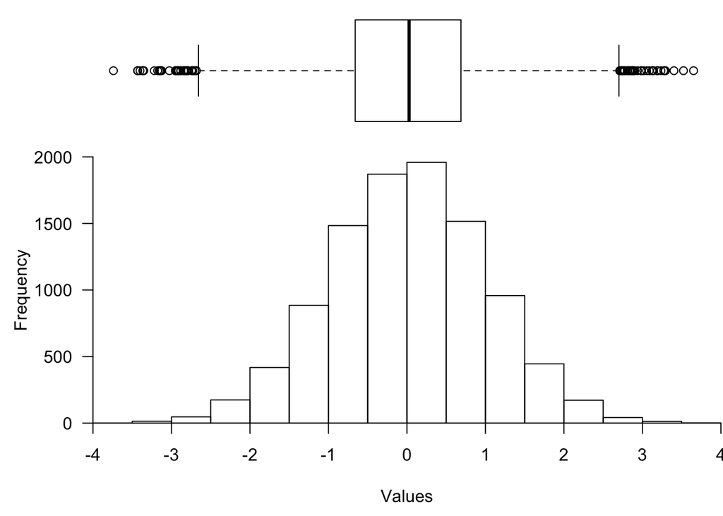

As a first step, we always look at the distributions of all of the quantitative variables in my data sets to better understand them and to check to see if anything looks unusual.

## 4.6 Examining two variables

### 4.6.1 Generate graphical comparisons of the two variables

Now, for the climax of data analysis—the scatter plot! There are other names for plots for which the horizontal and vertical axes are two variables one wishes to compare, but for not we’ll call is the scatter plot. A scatter plot will show the relationship between two variables, with points that represent each value for which there is a value for both variables. These plots are excellent for looking at relationships between two variables (correlations, but more on that below), such as height and weight, or how much time one spends at the mall and the difference in how much money they had from when they entered to when they left. (Do people still go to malls? Maybe time browsing Amazon is more *apropos*.) To generate a scatter plot, use `plot(x = , y = )` with your columns following each of those arguments.

### 4.6.2 Geneate an inferential statistic about the two variables

The Pearson Correlation Coefficient is a statistic that measures the linear correlation between two variables ([Wikipedia link](https://en.wikipedia.org/wiki/Pearson_correlation_coefficient#For_a_sample)). In other words, it reports the strength of the association between two variables. It’s denoted as *r* and varies between 1 and -1 to describe the strength of linear correlation between two variables. Here are some examples below:

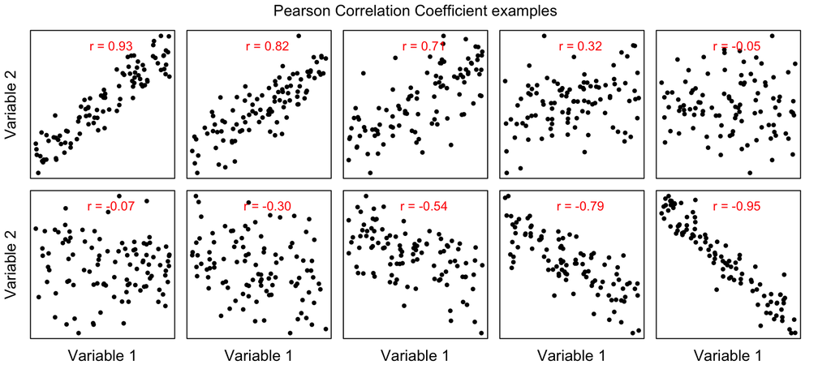

If you want to more finely-tune your intuition with real values of *r*, here’s a fun game that will allow you to do just that: [Guess the correaltion game](http://guessthecorrelation.com/).

To generate *r* in R, you can use the function `cor()`. It has two arguments like plot: `x =` and `y =` that you add your two variables to and it reports the Pearson Correlation Coefficient. However, we as scientists are interested in more than just the strength of the relationship; that is, we are interested if the relationship that we observe is different that random. To do this, we can run an inferential test using `cor.test()` that takes the same arguments (`x =` and `y =`). The function reports *r*, 95% confidence intervals of *r*, and the probability of our *r* given that the data are actually random—the *p*-value. To reiterate, a *p*-value tells you the probability of your data, given that there is actually no relationship between the two variables. Therefore, a large *p*-value (approaching 1) indicates that there is probably no relationship between the two variables, and a small *p*-value (approaching 0) indicates that there is probably a relationship between the two variables.

# 5 Report

This will be the first of 4 individual lab reports. Each report will be in the IMRaD format (**I**ntroduction, **M**ethods, **R**esults, and **D**iscussion), but will have different emphases. For this lab report, we wish to emphasize the methods and results, but include minor introduction and discussion sections. No outside sources are required for this report.

## 5.1 Introduction

A minor section in this lab report, we ask that you write a paragraph or two describing why we conducted this experiment. Please write it in such a way that you end with the experimental hypothesis.

## 5.2 Methods

A cornerstone in the scientific process is repeatability. If experiments aren’t repeatable, then other scientists cannot evaluate or build upon each other’s work. The methods section of a scientific paper is where scientists describe their experiment in enough detail that another scientist in their field should be able to repeat it nearly exactly.

For the methods section of your report, we ask that you describe what was done in the experiment, both in the field, and analytically. Please write in the active voice that includes a subject of the verb’s action (e.g., “We laid a transect” preferred over “A transect was laid”, or “I calculated the mean” over “The mean was calculated”). The section should be written with the amount of detail that an *Ecology* student in Fall 2019 could very closely replicate your experiment and analysis. It’d be helpful creating three subsections describing the study site (1 or 2 paragraphs), the field experiment (sufficient detail for repeatability), and analysis (1 or 2 paragraphs).

## 5.3 Results

The results section of a scientific paper is where the quantitative, ostensibly objective summary of the data is presented. It’s often a relatively short section, including summary and inferential statistics. Embedded within the text is often a few figures or tables that include the most pertinent relationships or findings within the study.

For this first report, we mostly want you to focus on generating figures and thoroughly describing them. Therefore, instead of a traditional results section with text and a few figures embedded, we ask that you create individual figures and write about each one in a caption below each figure.

With the data you collected, there are 4 variables (bearing, distance, depth, temperature) that we think could be responsible for abundance of 2 other variables (barnacle and alga abundance). In terms of the figures, graphically show the distribution of 4 of the 6 variables using 2 histograms and 2 box plots; that’s 4 figures. Next, graphically show the association of the two most important predictor variables for each response variable using scatter plots or box plots; that’s 4 figures. Last, show the association between the barnacles and algae; that’s 1 figure.

With each of the 9 figures, include a descriptive caption. Each caption should include

- A sentence describing the pattern in the data
- A sentence describing the axes
- A sentence describing the most relevant statistics (e.g., for a single variable, mean or mode might be the most important; for two variables, the Pearson Correlation Coefficient and *p*-value might be the most important)

## 5.4 Discussion

Another minor section in this lab report, we ask that you write as much as you’d like (perhaps a paragraph or two) evaluating the experimental hypothesis in light of the data you collected.